[OHI Science](http://ohi-science.org) | [Citation policy](http://ohi-science.org/citation-policy/)

# Examining SST Rate of Change

Compiled on Mon Dec 11 13:16:21 2017 by afflerbach

Objective: Compare different methods of deriving SST pressure layer. For the Ocean Health Index global, we compare the number of weekly SST anomalies in the most recent 5 years to the # of anomalies in the furthest 5 years (1985-1989). If we looked at rate of change in anomalies and rescaled according to rate, would that be a big difference?

# 1 Calculate mean annual SST and SST anomalies (SSTA)

For OHI we only calculated standard deviation so we had to calculate mean here.

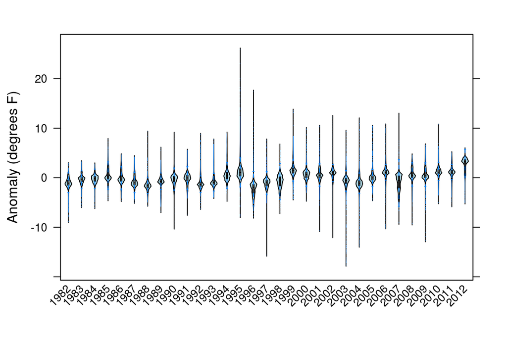

```
## [1] TRUE
```

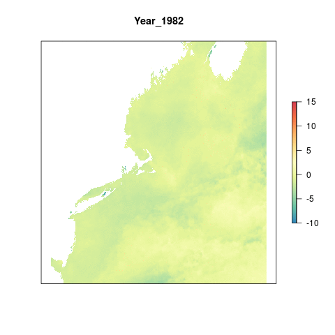

# 2 SST Rate of change

Calculates the trend per pixel from 1982 - 2012 for SST

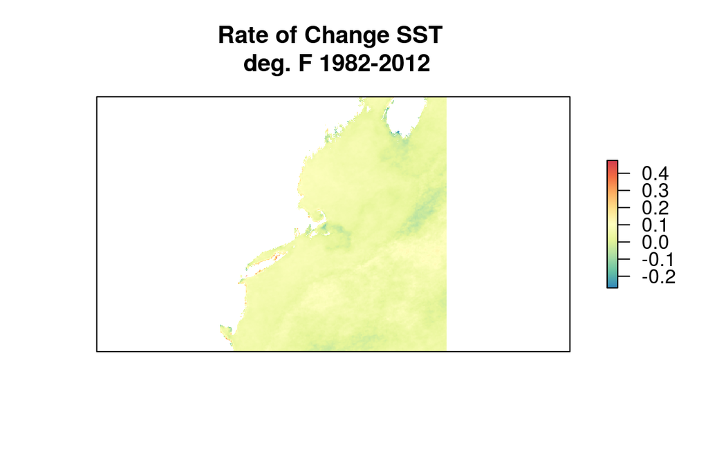

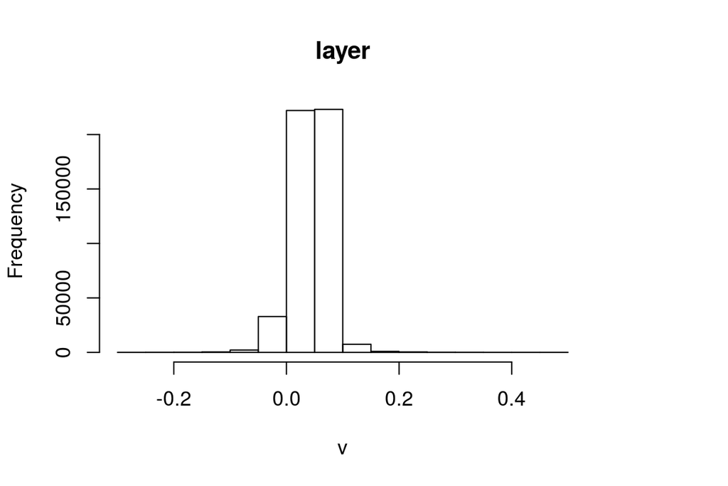

# 3 SST Difference in rate of change

Look at rate of change in only the last 10 years (2003-2012) compared to rate of change 1982-1991

To see how different the outcome is if we compare the first and last 5 years, we do the same thing but using 1982-1986 and 2008-2012.

# 4 SST Rescale using difference in rate - 5 years

[figure not shown]

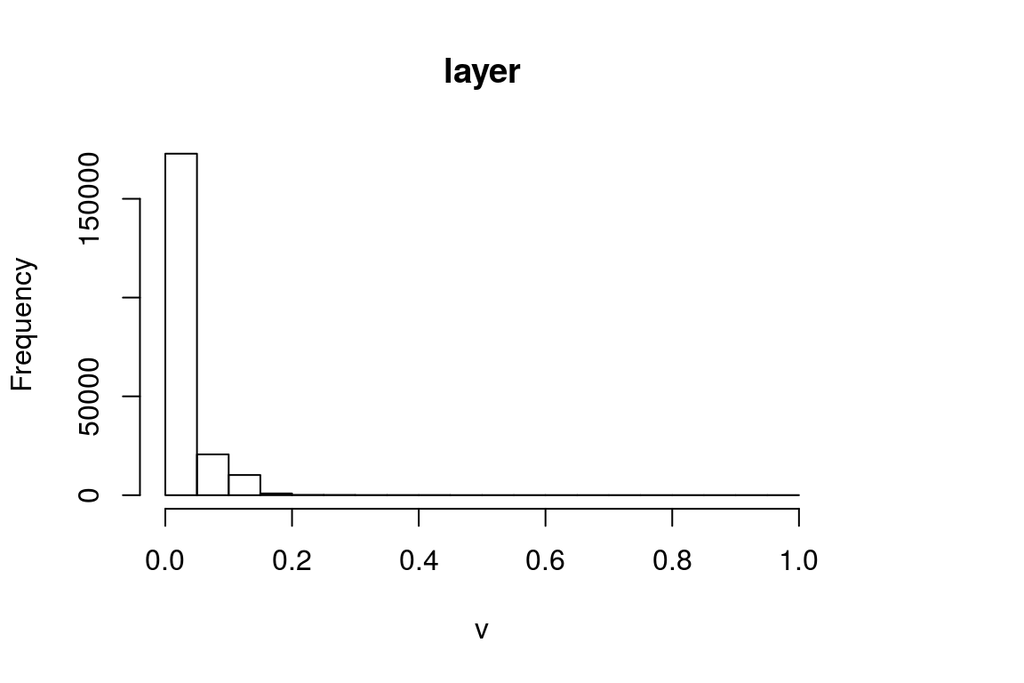

I ran the same exploration but with SSTA (sea surface temperature anomalies)

# 5 SSTA Rate of change

Calculates the trend per pixel from 1982 - 2012

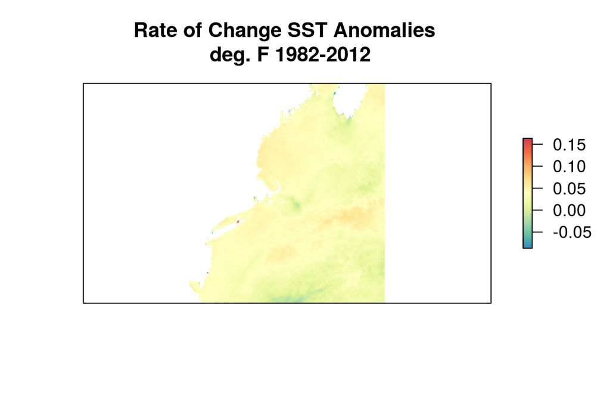

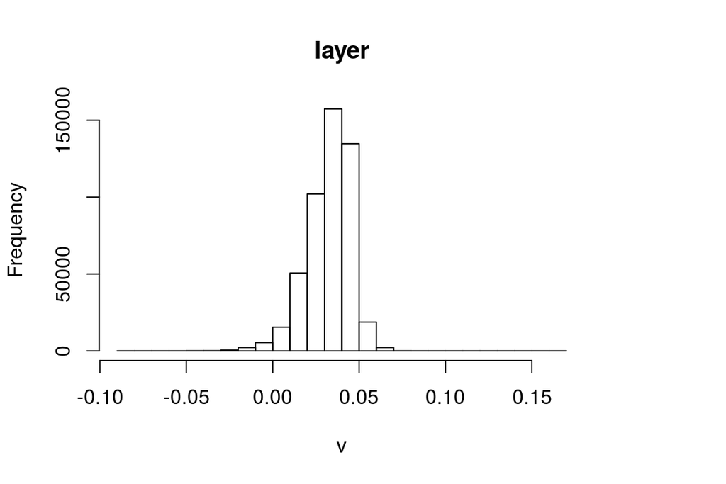

The mean change in SST anomaly is 0.033 degrees per year

# 6 SSTA Difference in rate of change

Look at rate of change in only the last 10 years (2003-2012) compared to rate of change 1982-1991?

To see how different the outcome is if we compare the first and last 5 years, we do the same thing but using 1982-1986 and 2008-2012.

# 7 SSTA Rescale using difference in rate - 5 years

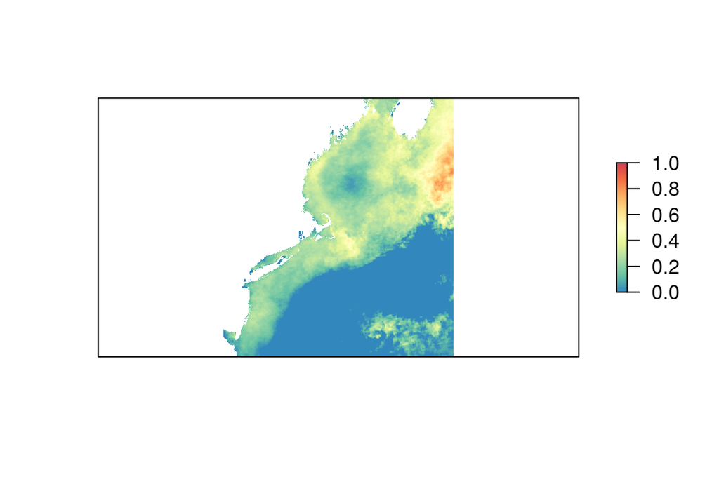

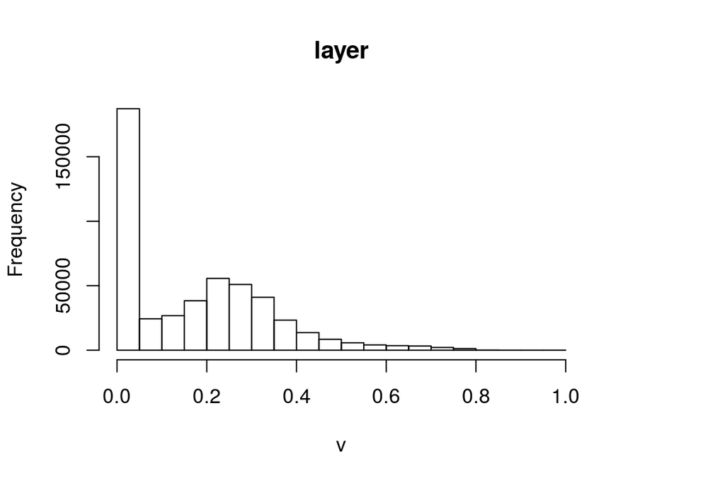